# Different data formats

Di Cook, Heike Hofmann  
1/24/2014

### Outline

- standard types in R
- object classes
- checking data quality

### Basic R objects

- Data types: numeric, integer, character, double
- Basic data structures: vector, matrix, character, factor, list

### Numeric values

Numeric objects have double precision, i.e. work with 53 bits

```r
pi <- as.numeric(gsub(" ","","3.14159 26535 89793 23846 26433 83279 50288 41971 69399 37510 58209 74944 59230"))
print(pi, digits=18) # digits maximum is 22, last few digits are suspicious
```

```
[1] 3.14159265358979312
```

Precision is machine dependent:

```r
1 + .Machine$double.eps == 1
```

```
[1] FALSE
```

```r
1 + .Machine$double.eps/2 == 1
```

```
[1] TRUE
```

```r
.Machine
```

```
$double.eps
[1] 2.22e-16

$double.neg.eps
[1] 1.11e-16

$double.xmin
[1] 2.225e-308

$double.xmax
[1] 1.798e+308

$double.base
[1] 2

$double.digits
[1] 53

$double.rounding
[1] 5

$double.guard
[1] 0

$double.ulp.digits
[1] -52

$double.neg.ulp.digits
[1] -53

$double.exponent
[1] 11

$double.min.exp
[1] -1022

$double.max.exp
[1] 1024

$integer.max
[1] 2147483647

$sizeof.long
[1] 8

$sizeof.longlong
[1] 8

$sizeof.longdouble
[1] 16

$sizeof.pointer
[1] 8
```

### Characters

Character covers all text formats.

```r
x <- "Hello World"
class(x)
```

```
[1] "character"
```

```r
is.character(x)
```

```
[1] TRUE
```

We will be dealing with text in much more detail when we are looking at regular expressions …

### Basic types in R

- Vectors: one-dimensional array of values of the same type; vectors have a length, but no dimension
- Matrix: two-dimensional array of values of the same type; matrices have a dimension given as (row, column), length returns the number of items (row x column)
- Array: any higher dimensional array (e.g. output of temperature data from netcdf data)

```r
x <- c("4.5", 3, TRUE, "elephant")
as.numeric(x) # note that the cast from logical to character doesn't survive intact
```

```
[1] 4.5 3.0  NA  NA
```

```r
length(x)
```

```
[1] 4
```

```r
X <- matrix(c(1,2,3, 11,12,13), nrow = 2,
   ncol=3, byrow=TRUE, dimnames =
   list(c("row1", "row2"), c("C.1", "C.2", "C.3")))
X
```

```
     C.1 C.2 C.3
row1   1   2   3
row2  11  12  13
```

### Data frames

Data frame: collection of vectors of same length but possibly different data type

```r
L3 <- LETTERS[1:3]
(d <- data.frame(cbind(x=1, y=1:10),
     fac=sample(L3, 10, replace=TRUE)))
```

```
   x  y fac
1  1  1   B
2  1  2   A
3  1  3   B
4  1  4   A
5  1  5   A
6  1  6   A
7  1  7   B
8  1  8   B
9  1  9   C
10 1 10   C
```

```r
str(d)
```

```
'data.frame':   10 obs. of  3 variables:
 $ x  : num  1 1 1 1 1 1 1 1 1 1
 $ y  : num  1 2 3 4 5 6 7 8 9 10
 $ fac: Factor w/ 3 levels "A","B","C": 2 1 2 1 1 1 2 2 3 3
```

### Lists

- lists allow the most flexibility, i.e. are not very structured.
- a list element can be anything, including another list
- very useful (and common) as output from analytic methods

```r
mod<-glm(mpg~cyl+disp+hp+drat+wt, data=mtcars)
head(str(mod))
```

```
List of 30
 $ coefficients     : Named num [1:6] 36.0084 -1.1075 0.0124 -0.024 0.9522 ...
  ..- attr(*, "names")= chr [1:6] "(Intercept)" "cyl" "disp" "hp" ...
 $ residuals        : Named num [1:32] -1.788 -0.852 -3.023 0.367 0.943 ...
  ..- attr(*, "names")= chr [1:32] "Mazda RX4" "Mazda RX4 Wag" "Datsun 710" "Hornet 4 Drive" ...
 $ fitted.values    : Named num [1:32] 22.8 21.9 25.8 21 17.8 ...
  ..- attr(*, "names")= chr [1:32] "Mazda RX4" "Mazda RX4 Wag" "Datsun 710" "Hornet 4 Drive" ...
 $ effects          : Named num [1:32] -113.65 -28.6 6.13 -3.06 -4.06 ...
  ..- attr(*, "names")= chr [1:32] "(Intercept)" "cyl" "disp" "hp" ...
 $ R                : num [1:6, 1:6] -5.66 0 0 0 0 ...
  ..- attr(*, "dimnames")=List of 2
  .. ..$ : chr [1:6] "(Intercept)" "cyl" "disp" "hp" ...
  .. ..$ : chr [1:6] "(Intercept)" "cyl" "disp" "hp" ...
 $ rank             : int 6
 $ qr               :List of 5
  ..$ qr   : num [1:32, 1:6] -5.657 0.177 0.177 0.177 0.177 ...
  .. ..- attr(*, "dimnames")=List of 2
  .. .. ..$ : chr [1:32] "Mazda RX4" "Mazda RX4 Wag" "Datsun 710" "Hornet 4 Drive" ...
  .. .. ..$ : chr [1:6] "(Intercept)" "cyl" "disp" "hp" ...
  ..$ rank : int 6
  ..$ qraux: num [1:6] 1.18 1.02 1.11 1.17 1.08 ...
  ..$ pivot: int [1:6] 1 2 3 4 5 6
  ..$ tol  : num 1e-11
  ..- attr(*, "class")= chr "qr"
 $ family           :List of 11
  ..$ family    : chr "gaussian"
  ..$ link      : chr "identity"
  ..$ linkfun   :function (mu)
  ..$ linkinv   :function (eta)
  ..$ variance  :function (mu)
  ..$ dev.resids:function (y, mu, wt)
  ..$ aic       :function (y, n, mu, wt, dev)
  ..$ mu.eta    :function (eta)
  ..$ initialize:  expression({     n <- rep.int(1, nobs)     if (is.null(etastart) && is.null(start) && is.null(mustart) && ((family$link ==          "inverse" && any(y == 0)) || (family$link == "log" && any(y <=          0))))          stop("cannot find valid starting values: please specify some")…
  ..$ validmu   :function (mu)
  ..$ valideta  :function (eta)
  ..- attr(*, "class")= chr "family"
 $ linear.predictors: Named num [1:32] 22.8 21.9 25.8 21 17.8 ...
  ..- attr(*, "names")= chr [1:32] "Mazda RX4" "Mazda RX4 Wag" "Datsun 710" "Hornet 4 Drive" ...
 $ deviance         : num 167
```

[output cut: 57 more lines]

```
  ..$ wt  : num [1:32] 2.62 2.88 2.32 3.21 3.44 ...
  ..$ qsec: num [1:32] 16.5 17 18.6 19.4 17 ...
  ..$ vs  : num [1:32] 0 0 1 1 0 1 0 1 1 1 ...
  ..$ am  : num [1:32] 1 1 1 0 0 0 0 0 0 0 ...
  ..$ gear: num [1:32] 4 4 4 3 3 3 3 4 4 4 ...
  ..$ carb: num [1:32] 4 4 1 1 2 1 4 2 2 4 ...
 $ offset           : NULL
 $ control          :List of 3
  ..$ epsilon: num 1e-08
  ..$ maxit  : num 25
  ..$ trace  : logi FALSE
 $ method           : chr "glm.fit"
 $ contrasts        : NULL
 $ xlevels          : Named list()
 - attr(*, "class")= chr [1:2] "glm" "lm"
```

### Working with lists

- single bracket operator [ ] returns sub-list
- double bracket operator [[ ]] returns single list element (i.e. only single positive integer is allowed)

```r
mod[c(1,6,8)]
```

```
$coefficients
(Intercept)         cyl        disp          hp        drat          wt
   36.00836    -1.10749     0.01236    -0.02402     0.95221    -3.67329

$rank
[1] 6

$family

Family: gaussian
Link function: identity
```

```r
mod[[1]]
```

```
(Intercept)         cyl        disp          hp        drat          wt
   36.00836    -1.10749     0.01236    -0.02402     0.95221    -3.67329
```

### Objects in R

```r
library(maptools)
xx <- readShapeSpatial(
  "../data/australia/region.shp")
class(xx)
```

```
[1] "SpatialPolygonsDataFrame"
attr(,"package")
[1] "sp"
```

```r
slotNames(xx)
```

```
[1] "data"        "polygons"    "plotOrder"   "bbox"        "proj4string"
```

```r
xx@bbox
```

```
     min     max
x  96.82 159.109
y -43.74  -9.142
```

- special functions can be implemented to deal with S3 objects. These are called **methods**

```r
methods(class=class(xx))
```

```
[1] as.data.frame.SpatialPolygonsDataFrame*
[2] dim.SpatialPolygonsDataFrame*
[3] length.SpatialPolygonsDataFrame*
[4] names.SpatialPolygonsDataFrame*
[5] names<-.SpatialPolygonsDataFrame*
[6] rbind.SpatialPolygonsDataFrame
[7] row.names.SpatialPolygonsDataFrame*
[8] row.names<-.SpatialPolygonsDataFrame*

   Non-visible functions are asterisked
```

```r
head(as.data.frame(xx))
```

```
  ELECT_DIV STATE NUMCCDS ACTUAL PROJECTED POPULATION OVER_18 AREA_SQKM
0  Lingiari    NT     335      0         0          0       0 1352034.1
1   Solomon    NT     180      0         0          0       0     336.7
2  Canberra   ACT     283      0         0          0       0    1920.5
3    Fraser   ACT     270      0         0          0       0     505.2
4     Brand    WA     243      0         0          0       0     410.5
5   Canning    WA     268      0         0          0       0    6178.0
  SORTNAME
0 Lingiari
1  Solomon
2 Canberra
3   Fraser
4    Brand
5  Canning
```

### Cleaning data

Most data scraped from the web (or from more official sources) come in various shapes of cleanliness.

Our definition of clean: data suitable for further analysis (rectangular shaped: records in rows, variables in columns, first row contains variable names = first normal form)

- units do not belong with the numbers
- commas to bundle three digits change number format to text
- missing values should be made `NA`s

### Example: NBA salaries

ESPN provides basketball players' salaries for the 2013-2014 season at [http://espn.go.com/nba/salaries]

```r
library(XML)
nba14 <- NULL
for (i in 1:50) {
  temp <- readHTMLTable(
    sprintf("http://espn.go.com/nba/salaries/_/page/%d",i))[[1]]
  nba14 <- rbind(nba14, temp)
}
head(nba14)
```

```
  V1                    V2                 V3          V4
1 RK                  NAME               TEAM      SALARY
2  1       Kobe Bryant, SG Los Angeles Lakers $30,453,805
3  2     Dirk Nowitzki, PF   Dallas Mavericks $22,721,381
4  3 Amar'e Stoudemire, PF    New York Knicks $21,679,893
5  4       Joe Johnson, SG      Brooklyn Nets $21,466,718
6  5   Carmelo Anthony, SF    New York Knicks $21,388,953
```

```r
str(nba14)
```

```
'data.frame':   656 obs. of  4 variables:
 $ V1: Factor w/ 565 levels "1","10","11",..: 41 1 12 23 34 36 37 38 39 40 ...
 $ V2: Factor w/ 565 levels "Al Jefferson, C",..: 31 26 15 2 21 8 16 33 9 28 ...
 $ V3: Factor w/ 34 levels "Brooklyn Nets",..: 21 11 5 16 1 16 8 11 13 13 ...
 $ V4: Factor w/ 401 levels "$12,350,000",..: 37 36 35 34 33 32 31 30 29 29 ...
```

### Cleaning NBA salaries data

The data is reasonably well oragnized, but in typical shape for scraped data

```r
# get first line of data into header
nba14[1,]
```

```
  V1   V2   V3     V4
1 RK NAME TEAM SALARY
```

```r
as.character(unlist(nba14[1,])) # why unlist? - compare to result without
```

```
[1] "RK"     "NAME"   "TEAM"   "SALARY"
```

```r
as.character(nba14[1,])
```

```
[1] "41" "31" "21" "37"
```

```r
names(nba14) <- as.character(unlist(nba14[1,]))
nba14 <- nba14[-1,]
```

### Cleaning NBA salaries data

```r
head(nba14$SALARY)
```

```
[1] $30,453,805 $22,721,381 $21,679,893 $21,466,718 $21,388,953 $20,513,178
401 Levels: $12,350,000 $12,433,735 $12,500,000 $12,868,632 ... $28,834
```

```r
# get rid of $ and , in salaries and convert to numeric:
gsub("[$,]", "", head(as.character(nba14$SALARY)))
```

```
[1] "30453805" "22721381" "21679893" "21466718" "21388953" "20513178"
```

```r
nba14$SALARY <- as.numeric(gsub("[$,]", "", as.character(nba14$SALARY)))
```

```
Warning: NAs introduced by coercion
```

Where does the warning come from?

### Cleaning NBA salaries data: hunting the warning

```r
head(subset(nba14, is.na(SALARY)))
```

```
   RK NAME TEAM SALARY
12 RK NAME TEAM     NA
23 RK NAME TEAM     NA
34 RK NAME TEAM     NA
45 RK NAME TEAM     NA
56 RK NAME TEAM     NA
67 RK NAME TEAM     NA
```

We don't need these rows - delete all of them

```r
dim(nba14)
```

```
[1] 655   4
```

```r
nba14 <- nba14[-which(nba14$RK=="RK"),]
dim(nba14)
```

```
[1] 564   4
```

### Cleaning NBA data

Separate names into first, last, and position

```r
library(stringr)
splits <- str_split(as.character(nba14$NAME), pattern="(, )| ")
splits[1:3]
```

```
[[1]]
[1] "Kobe"   "Bryant" "SG"

[[2]]
[1] "Dirk"     "Nowitzki" "PF"

[[3]]
[1] "Amar'e"     "Stoudemire" "PF"
```

```r
library(plyr)
numnames <- ldply(splits, length)
summary(numnames) # some players have multiple names, ... sigh
```

```
       V1
 Min.   :3.00
 1st Qu.:3.00
 Median :3.00
 Mean   :3.02
 3rd Qu.:3.00
 Max.   :6.00
```

### Cleaning data

There's only limited possibilities in terms of what we can do automatically about people with multiple names - we will deal with them alongside the other ones and flag them … maybe we should leave first and last name together

```r
head(splits[numnames>3], 5)
```

```
[[1]]
[1] "Luc"     "Richard" "Mbah"    "a"       "Moute"   "PF"

[[2]]
[1] "Otto"   "Porter" "Jr."    "SF"

[[3]]
[1] "John"  "Lucas" "III"   "PG"

[[4]]
[1] "Metta" "World" "Peace" "SF"

[[5]]
[1] "Nando" "de"    "Colo"  "PG"
```

```r
sum(numnames>3)
```

```
[1] 8
```

### Cleaning NBA data

```r
splitnames <- ldply(splits, function(x) c(name=paste(x[-length(x)], collapse=" "), position=x[length(x)]))
head(splitnames) # looks OK
```

```
               name position
1       Kobe Bryant       SG
2     Dirk Nowitzki       PF
3 Amar'e Stoudemire       PF
4       Joe Johnson       SG
5   Carmelo Anthony       SF
6     Dwight Howard        C
```

```r
# now copy into the nba14 data frame
nba14$name <- as.factor(splitnames$name)
nba14$position <- as.factor(splitnames$position)
```

### Cleaned data ...?

```r
summary(nba14)
```

```
       RK                         NAME                      TEAM
 1      :  1   Al Jefferson, C      :  1   null Unknown       : 32
 10     :  1   Amar'e Stoudemire, PF:  1   Memphis Grizzlies  : 26
 11     :  1   Andre Iguodala, SF   :  1   Cleveland Cavaliers: 22
 12     :  1   Andrew Bogut, C      :  1   Philadelphia 76ers : 22
 13     :  1   Ben Gordon, SG       :  1   Atlanta Hawks      : 21
 14     :  1   Blake Griffin, PF    :  1   Charlotte Bobcats  : 20
 (Other):558   (Other)              :558   (Other)            :421
     SALARY                    name        position
 Min.   :   20103   Chris Johnson:  2   SG     :120
 1st Qu.:  826495   Chris Wright :  2   PF     :115
 Median : 1893920   Aaron Gray   :  1   SF     :112
 Mean   : 3757812   Acie Law     :  1   PG     :108
 3rd Qu.: 4825396   Al Horford   :  1   C      : 98
 Max.   :30453805   Al Jefferson :  1   NA     :  7
                    (Other)      :556   (Other):  4
```

Who knows about this team null Unknown?

```r
nba14$TEAM[nba14$TEAM=="null Unknown"] <- NA
```

### Cleaned data ...?

Numbers might still be wrong, but now we are in a position to check for that.

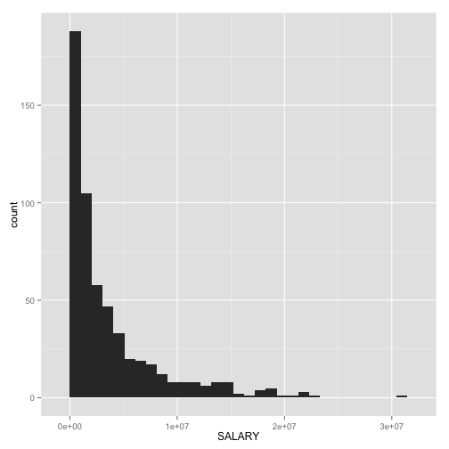

```r
library(ggplot2)
qplot(SALARY, geom="histogram", data=nba14)
```

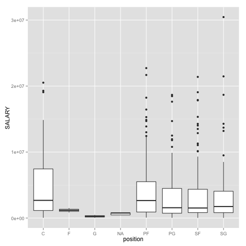

```r
qplot(position, SALARY, geom="boxplot", data=nba14)
```

### READING

[Working with date and time: http://www.jstatsoft.org/v40/i03/](http://www.jstatsoft.org/v40/i03/)

- What are intervals, durations, periods, and instants?
- (Why) do we need these distinctions?

Make a blog entry by 3pm Wednesday, Jan 29.